# State Republican Party Says Afghan Refugees Not Welcome In Oklahoma | Public Radio Tulsa

[interactive chart not shown]

# State Republican Party Says Afghan Refugees Not Welcome In Oklahoma

By [Chris Polansky](https://www.publicradiotulsa.org/people/chris-polansky) *•* Sep 8, 2021

[figure not shown]

- Oklahoma Republican Party Chair John Bennett in a video posted to the party's Facebook page on Saturday, Sept. 4, saying the state should not welcome Afghan refugees fleeing the Taliban.

  Oklahoma Republican Party

The Oklahoma Republican Party on Saturday said the state should not welcome Afghan refugees fleeing Taliban rule following the U.S. military withdrawal from Afghanistan.

In a video posted to the party's Facebook page, party chair John Bennett called on Oklahomans to speak up about the fact that they are anti-refugee.

"I encourage you to call and email the governor, call and email your legislators, and tell them: Do not allow Afghan refugees into Oklahoma," said Bennett, who, in addition to leading the state GOP, is also an Assembly of God preacher at a church in Muldrow.

Several prominent Oklahoma Republicans, including Gov. Kevin Stitt and U.S. Sen. James Lankford, have said Afghan refugees will be welcomed to the state with open arms. Republican Tulsa Mayor G.T. Bynum [said last month](https://www.facebook.com/gtbynumfortulsamayor/posts/2905312029797506) he had signed up to assist Catholic Charities of Eastern Oklahoma in resettling the refugees.

Bennett, a Marine Corps veteran of the war in Afghanistan, claimed the federal government, led by "former Vice President Biden," was allowing "unvetted refugees" who are "enemies" of the United States into the country and the state.

"They don't have any way to vet non-American citizens," Bennett said. "I was on the ground in Afghanistan and there is no way you can properly vet these people. If the government says otherwise, they are lying to you."

The State Department [does say otherwise](https://www.state.gov/briefings/department-press-briefing-august-19-2021/), noting that Special Immigrant Visa-holding Afghans have undergone rigorous background checks and vetting, and evacuated Afghans seeking refuge in the U.S. who do not yet have documentation are being transported to third-party countries pending such vetting.

Bennett, who was elected party chair after multiple instances of spreading anti-Muslim rhetoric, also uses the video to propagate those beliefs, prompting the Council on American-Islamic Relations' Oklahoma chapter to issue a statement of condemnation.

“John Bennett has a long history dating back to 2013 of offensive attacks on Islam and the Oklahoma Muslim community,” executive director Adam Soltani said. “It is past time that Republicans speak out and he be removed from a position of authority as he has proven repeatedly that he is unhinged and seeks only to spread hate, divisiveness, and promote violence towards innocent Muslims in our state and country.”

The Oklahoma Republican Party earlier this year drew the condemnation of Jewish groups after the party compared COVID-19 public health measures in the U.S. to atrocities committed against Jews by Nazi Germany, using Holocaust imagery to fundraise.

[john bennett](https://www.publicradiotulsa.org/term/john-bennett)

[oklahoma republican party](https://www.publicradiotulsa.org/term/oklahoma-republican-party)

[War in Afghanistan](https://www.publicradiotulsa.org/term/war-afghanistan)

[Afghanistan](https://www.publicradiotulsa.org/term/afghanistan)

## [Stitt, Lankford Say Oklahoma Welcomes Afghan Refugees](https://www.publicradiotulsa.org/post/stitt-lankford-say-oklahoma-welcomes-afghan-refugees)

By [Chris Polansky](https://www.publicradiotulsa.org/people/chris-polansky) *•* Aug 19, 2021

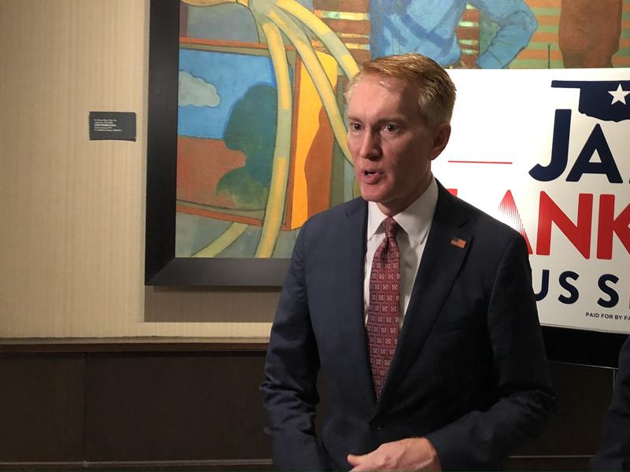

Chris Polansky / KWGS News

Two prominent Republican voices in Oklahoma said Wednesday the state should and will welcome Afghan refugees who assisted the U.S. mission in Afghanistan and are now seeking safety from the new Taliban government.

"Governor Stitt welcomes Afghans fleeing the terrorist Taliban regime to come to Oklahoma and live in the freedom we hold so dearly," Stitt spokeswoman Carly Atchison said in a statement. "Our office is exploring every possible avenue to help to ensure no American citizen nor any of our allies are left behind."

## [Oklahoma Republican Party Triples Down On Fundraising Off Vaccine Policy-Nazi Germany Comparison](https://www.publicradiotulsa.org/post/oklahoma-republican-party-triples-down-fundraising-vaccine-policy-nazi-germany-comparison)

By [Chris Polansky](https://www.publicradiotulsa.org/people/chris-polansky) *•* Aug 4, 2021

[figure not shown]

Oklahoma Republican Party

The Oklahoma Republican Party on Wednesday morning reaffirmed its belief that requirements for individuals to be vaccinated against COVID-19 are akin to the treatment of Jews in Nazi Germany.

"You elected me to fight for you, and that is what I'm going to do," said party chair John Bennett in a Wednesday [video message](https://www.facebook.com/events/4045120478943441?ref=newsfeed) that ended in an appeal for donations.

## [Oklahoma Republican Party Doubles Down On COVID Vaccine Policy-Holocaust Comparison](https://www.publicradiotulsa.org/post/oklahoma-republican-party-doubles-down-covid-vaccine-policy-holocaust-comparison)

By [Chris Polansky](https://www.publicradiotulsa.org/people/chris-polansky) *•* Aug 2, 2021

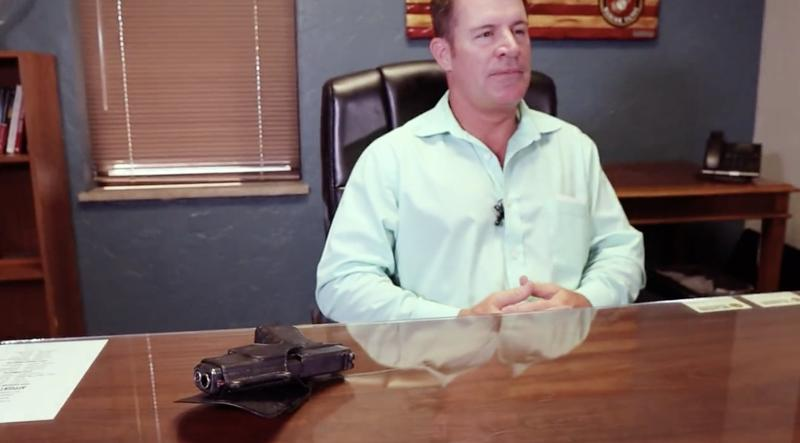

Oklahoma Republican Party

The Oklahoma Republican Party is refusing to back down from an offensive Facebook post made Friday in which they compared private employers requiring their workers be vaccinated against COVID-19 to the treatment of Jews in Nazi Germany.

The [Friday post](https://www.facebook.com/OKGOP/posts/10157912291970706), which suggested unvaccinated Americans are being treated the same as the Jews murdered during the Holocaust, drew rebukes from Jewish groups and some Republicans, but party officials not only left it online but attempted to use it to raise funds.

## [Oklahoma GOP Continues Holocaust Rhetoric At Capitol Rally Opposing Public Health Measures](https://www.publicradiotulsa.org/post/oklahoma-gop-continues-holocaust-rhetoric-capitol-rally-opposing-public-health-measures)

By [Chris Polansky](https://www.publicradiotulsa.org/people/chris-polansky) *•* Aug 16, 2021

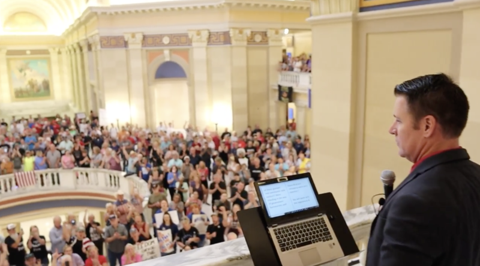

Oklahoma Republican Party

At a Saturday rally inside the Oklahoma State Capitol opposing COVID-19 public health measures, the Oklahoma Republican Party continued its now-familiar messaging comparing pandemic-related policies to Nazi Germany and its atrocities.

The party promoted [the rally](https://www.facebook.com/OKGOP/videos/251117303357711), attended by several hundred demonstrators, with the hashtags #NoMasks, #NoLockdowns and #NoVaccineMandates.